# Coregistration of MSI and H&E images of the Farmhouse painting dataset

Sai Srikanth Lakkimsetty

Apr, 2024

# Contents

# 1 Setup

Load necessary packages.

# 2 Introduction

In this vignette, we illustrate the coregistration between mass spectrometry image and H&E images of the farmhouse painting which is affixed onto a glass slide.

The MSI is acquired with a DESI ionization source using a LTQ linear ion trap mass spectrometer (Thermo Fannigan). The mass spectra are acquired between 100 and 1000 m/z for a total of 10,800 features.

There are four key inputs to the coregistration workflow. These are the fixed image, the moving image, MSI region of interest (ROI) and optical image ROI. We consider the MS image as the *moving image* and the optical image as the *fixed image*. That means, the MS image is transformed to align with the microscopic (H&E) image. The ROIs provide the coregistration method with information on where the tissue is present on the slide. It is essential that the coregistration method knows where the background is present to exclude it from coregistration process. Not only does this improve the computational efficiency of the method, it also results in a better coregistration performance.

Similarly there are four key steps to coregistering MS and optical images. We shall discuss more about the steps as we perform them.

- Pre-processing MS and optical images
- ROI selection of the images
- Pre-alignment
- Coregistration

We load the MS and optical images into R as below. (We also set directories for saving the environment and the transformation files.)

DATAPATH, and CURRPATH are directories to indicate where the data is stored. ENVSAVEPATH is the directory to save the global environment after the coregistration is completed so we can avoid re-running the coregistration method if we want to visit the results again later. TFSAVEPATH is the directory to store the transformation R object (R object responsible for how the alignment is done) separately. This is due to the fact how SimpleITK stores data in R objects.

However, if you do not want to save the R environment or the transformation objects, skip the below two chunks and directly read MSI and H&E images below.

```r
DATAPATH <- "/Users/sai/Documents/00-NEU/2-Ind-Study/9-data"
CURRPATH <- "5-farmhouse"
ENVSAVEPATH <- "/Users/sai/Library/Mobile Documents/com~apple~CloudDocs/1-saved-envs/vignettes/msireg-vignettes"
TFSAVEPATH <- "/Users/sai/Documents/01-NU/phd/msireg/data/saved-transforms/msireg-vignettes"

mse_data <- "farmhouse.rdata"
opt_filename <- "farmhouse.png"
env_filename <- "6-farmhouse.RData"
tf_filename <- "6-farmhouse.hdf5"
```

Below are some utility functions for allowing us to quickly save and load R environment (when performing coregistration and any downstream analyses in multiple R sessions), and IO for transformation files. Skip this step if you do not want to save the R environment or the transformation objects after running the coregistration method.

```r
saveImage <- function(filename) {
    save.image(file.path(ENVSAVEPATH, filename))
}


loadImage <- function(filename) {
    load(file.path(ENVSAVEPATH, filename), envir=.GlobalEnv)
}


writeTF <- function(coregister_object, filename) {
    WriteTransform(coregister_object$reg$TF,
        file.path(TFSAVEPATH, filename))
}


readTF <- function(coregister_object, filename) {
    coregister_object$reg$TF <- ReadTransform(
        file.path(TFSAVEPATH, filename)
    )
    coregister_object
}
```

Finally, we load into R the MSI and histology images. Change directory MSI and H&E images

```r
load(file.path(DATAPATH, CURRPATH, mse_data))
mse_peaks <- as(farmhouse, "MSImagingExperiment")

opt <- readImage(file.path(DATAPATH, CURRPATH,
    opt_filename))
opt |> display("raster")

saveImage(env_filename)
```

# 3 MS image pre-processing

The MSI data we imported is already preprocessed. The peak picked and filtered data has 187 features. So, no further processing is needed.

# 4 Identifying regions-of-interest (ROIs)

In this section, we refer to the tissue outline which demarcates the boundary between the tissue areas and background as a region of interest (ROI). ROI (in the context of coregistration) implies the whole tissue and not just the “interesting” regions within the tissue that we may be interested in.

First, we make a list of the processed data attributes: X and Y spatial resolution of processed MSI data; number of features and pixels of processed MSI data; and X and Y spatial resolution of optical image.

```r
mse_attrs <- list(
    nX = dims(mse_peaks)[1], nY = dims(mse_peaks)[2],
    nF = dim(mse_peaks)[1], nP = dim(mse_peaks)[2],
    nXo = dim(opt)[1], nYo = dim(opt)[2]
)
```

## 4.1 MSI tissue outline

Tissue outline is a binary mask i.e., a TRUE or FALSE flag for each pixel indicating whether that pixel is part of the tissue (TRUE) or part of the backgroud (FALSE).

MSI’s tissue outline can be computed in two ways. Often, if the tissue is imaged (likely in MALDI) where only the tissue areas are ionized and imaged, then the function `constructROIFromMSImage()` will automatically generate a mask separating background from the tissue.

However, if the MSI includes background as well (for example, DESI), then `msireg` provides an in-built utility to generate the tissue ouline for MSI tissue. We select the tissue outline using the function `multiSelectROI` which is built on `Cardinal`’s `selectROI` method. `multiSelectROI` can select multiple disjoint tissue regions in one go. The method `multiSelectROI` needs an `mz` value to display a raster on which the tissue outline is selected.

If you already have a `mz` value that properly demarcates tissue and background, skip the next two code chunks. Otherwise, we build a quick spatial shrunken centroids model (refer `?spatialShrunkenCentroids` for details) to come up with a list of `mz` values that are suitable for this task. The `mz` list is derived from the `ssc` model’s top features. This is a reliable way to select one `mz` value for tissue outline selection. Please note that this is a computational heavy step and may take a few minutes; it may be easier to select a `mz` value manually.

```r
set.seed(2)
ssc <- spatialShrunkenCentroids(mse_peaks, r=c(1), s=c(24), k=c(15),
    method="gaussian", BPPARAM=MulticoreParam())
topf <- topFeatures(ssc, n=10, model=list(s=24))$mz
```

Now we select a `mz` value from the top features `topf`. `mz =` 323.25 is a good ion image to draw MSI issue outline.

```r
image(mse_peaks, mz=t323.25)
message("Appropriate m/z value for tissue outline selection: ",
    round(323.25, 3))
```

To select the tissue outline using a mouse on the plotting pane, run the below command directly from console. We specify the `mz` value we selected above. In fact, `multiSelectROI` can be used on a variety of plotting types including superposed image plots.

```r
# RUN DIRECTLY FROM CONSOLE, SESSION WILL CRASH OTHERWISE
# mse_roi <- multiSelectROI(mse_peaks, mz=323.25)
```

## 4.2 Histology image tissue outline

We use `multiDrawROI` to select the tissue outline for optical images. The usage is identical to that of `multiSelectROI` (without the need for a `mz` value). It is to be executed directly from console to prevent R session from crashing. The histology images can have high spatial resolution leading to high tissue outline computational times.

```r
# RUN DIRECTLY FROM CONSOLE, SESSION WILL CRASH OTHERWISE
# opt_roi <- multiDrawROI(opt)
```

# 5 Pre-alignment of images

So far, we have performed pre-processing and tissue outline selection of the images. Before doing the coregistration step, we further process the images to ensure the images are overlapping. Often, the tissues on the imaged slide are at different (non-overlapping) positions. That means, the burden of first bringing the images together falls on the coregistration method, which could affect its performance. To alleviate this problem, we ensure overlap of two images by cropping and padding. We crop and/or pad histology image so that it overlaps with the tissue of the MS image. To clarify, we are not coregistering the images in this step (no transformations of the grid) but we do keep track of the the cropping and padding operations to ensure reproducibility.

```r
OUT <- cropToEdgesAndPadZeros(ref_mask=mse_roi,
    target_mask=opt_roi, target_img=opt)
opt <- OUT$img
opt_roi <- OUT$mask
```

# 6 Coregistration

Here, we coregister the MS image (pre-processed `mse_peaks`) and the optical image (`opt`) using the `coregister()` function. A scaling factor, `spatial_scale`, allows the method to coregister the images at a higher / lower resolution (with respect to the `mse`’s spatial dimensions). This is to overcome the imaging resolution disparity between MSI and optical images. The method returns a list. The individual coregistration components can be accessed using the `$`.

```r
OUT <- coregister(mse=mse_peaks, opt=opt, mse_roi=mse_roi,
    opt_roi=opt_roi, spatial_scale=4,
    BPPARAM=MulticoreParam(), verbose=TRUE)
```

Next, we save the environment and the transformation parameters to file. This way, we can work with the coregistration outputs later in another session without having to run `coregister()` again. This is step is recommended because `R` / `SimpleITK` may overwrite the `OUT` object in the following steps.

```r
saveImage(env_filename)
writeTF(OUT, tf_filename)

# loadImage(env_filename)
# OUT <- readTF(OUT, tf_filename)
```

Because of the same reasons for writing `OUT` object to file, let’s go ahead and duplicate the object as well for extra safety. This duplicates the whole object and not just the reference pointer to the same object in memory.

```r
out <- rlang::duplicate(OUT)
```

# 7 Visualization of the results

We visualize the results of the coregistration. Before visualization, we need to generate the transformed moving image that aligns correctly with the fixed image. We use the method `Resample()` from `SimpleITK` to obtain the transformed moving image. The plot below shows the overlays of the MS (moving) image and the optical (fixed) images’ overlays before and after coregistration.

A few details we use throughout the rest of the vignette:

- Visualizing `SimpleITK::image()` objects is buggy in R, so we convert them to `EBImage::Image()` objects and visualize them.
- `out$fixed` is the fixed image, `out$moving` is the moving image, `out$movingx` is the transformed moving image.

```r
out$fixed <- SimpleITK::as.image(out$opt, isVector=FALSE)
out$moving <- SimpleITK::as.image(out$msimg, isVector=FALSE)

# Generate the transformed and aligned moving image
out$movingx <- Resample(out$moving, out$reg$TF)
```

[figure not shown]

```r
alpha <- 0.45

# Convert SimpleITK's image() objects into EBimage's Image() objects for easier and flexible plotting
.fixed <- out$fixed |> as.array() |> Image()
.moving <- out$moving |> as.array() |> Image()
.movingx <- out$movingx |> as.array() |> Image()

# Overlay fixed and moving images
ol1 <- (.fixed * alpha + .moving * (1-alpha))

# Overlay fixed and transformed moving images
ol2 <- (.fixed * alpha + .movingx * (1-alpha))

# Plot fixed, moving, and overlays before and after coregistration
def.par <- par(no.readonly=TRUE)
height <- 11
width <- height * (dim(.fixed)[1] / dim(.fixed)[2])

titles <- c("Optical image", "Mass spec. image",
            "Overlay before coregistration", "Overlay after coregistration")

par(mar=c(0.25, 0.25, 0.75, 0.25))
pl <- layout(mat=matrix(c(1:4), ncol=2, byrow=TRUE),
             heights=rep(height/2, 2), widths=rep(width/2, 2),
             respect=TRUE)

. <- sapply(c(1:4), function(x) {
    plot.new()
    rasterImage(list(.fixed, .moving, ol1, ol2)[[x]],
                xleft=0, xright=1, ytop=0, ybottom=1,
                interpolate=FALSE)
    title(titles[x])
})
par(def.par)
```

As we can see, the representative MS image shows heterogeneity that is comparable to the optical image. The bottom row shows overlays of the optical and MS image before and after coregistration.

Next, we visualize the transformation parameters. By deforming a square grid, we can visualize how the coregistration method “moved” the moving image so it is coregistered or aligned with the fixed image. This step allows us to identify anomalies, failed coregistrations, or folding.

```r
overlay <- overlayGridOnImage(out$msimg, scale_factor=1)$overlay |> as.image()
grid <- overlayGridOnImage(out$msimg, scale_factor=1)$grid |> as.image()

out$overlayx <- Resample(overlay, out$reg$TF) |> as.array() |> Image()
out$gridx <- Resample(grid, out$reg$TF) |> as.array() |> Image()
```

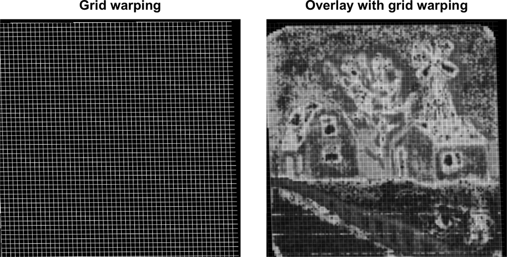

```r
height <- 7
width <- (height * 2) * (dim(out$gridx)[1] / dim(out$gridx)[2])

pl <- layout(mat=matrix(c(1:2), ncol=2, byrow=TRUE),
             heights=height, widths=rep(width/2, 2),
             respect=TRUE)
titles <- c("Grid warping", "Overlay with grid warping")
par(mar=c(0.25, 0.25, 0.75, 0.25))
. <- sapply(c(1:2), function(x) {
    plot.new()
    rasterImage(list(out$gridx, out$overlayx)[[x]],
                xleft=0, xright=1, ytop=0, ybottom=1,
                interpolate=TRUE)
    title(titles[x])
})
par(def.par)
```

In the above plot, the left plot shows how the deformation of the grid shows how underlying coordinate system has been transformed (warped) by the coregistration method so the moving image tissue aligns with the fixed image. The expansions and contractions correspond to those in the transformed moving image as shown in the right plot. If the grid plot has aliasing issues, plot the grid separately using the below chunk utilizing the full width of the page.

```r
height <- 8
width <- (height) * (dim(out$gridx)[1] / dim(out$gridx)[2])

pl <- layout(mat=matrix(c(1), ncol=1, byrow=TRUE),
             heights=height, widths=width,
             respect=TRUE)
titles <- c("Grid warping")
par(mar=c(0.25, 0.25, 0.75, 0.25))
plot.new()
rasterImage(out$gridx, xleft=0, xright=1, ytop=0, ybottom=1,
                interpolate=TRUE)
title(titles[1])
```

```r
par(def.par)
```

# 8 Performance metrics

There is no **single** metric that evaluates all aspects of the coregistration. However, a set of metrics are included in the package and tuned to answer specific aspects. Some of them are below.

- Sørensen-Dice coef. - Dice
- Normalized gradient field - Modersitzki & Haber
- Mutual information (MI) - Viola & Wells
- Normalized MI - Studholme et. al.
- Dense vector field jacobian
- Gradient field cosine distance

## 8.1 Sørensen-Dice Similarity Coefficient<sup>[[1](https://support.brainvoyager.com/images/documents/Available_Tools/Available_Scripts/python/ImageRegistrationEvaluationViaDiceCoefficientInBV_v02.pdf)]</sup>

The Dice coefficient, `D` is essentially the percentage of area that is overlapping between the optical and MS image.

$A$, $B$ are the images represented on the coordinate grid. $\cap$ represents the overlapped area between two images.

$$D = \frac{2 \mid A \cap B \mid}{\mid A \mid + \mid B \mid}$$

Dice coefficient is computed from MSI and OPT tissue outlines or masks. The range of Dice coefficient varies between `0` and `1`. `0` means complete misalignment and `1` means perfect alignment. This metric evaluates the degree of overlap between the tissue outlines before and after coregistration.

```r
spatial_scale <- 4
DIM <- dim(out$MSIMG)[1:2] * spatial_scale
D_prereg <- diceCoefFromMasks(mse_roi, opt_roi)
mse_roi_ss <- resizeAndPadImageToMatchDims(mse_roi, DIM)
opt_roi_ss <- resizeAndPadImageToMatchDims(opt_roi, DIM)
mse_roi_ss_x <- applyTransformOnMask(mse_roi_ss, out$reg$TF)
D_postreg <- diceCoefFromMasks(mse_roi_ss_x, opt_roi_ss)
```

Dice coefficient before and after coregistration is 0.967 and 0.978 respectively. We can also overlay the tissue outlines and visualize the alignment as below.

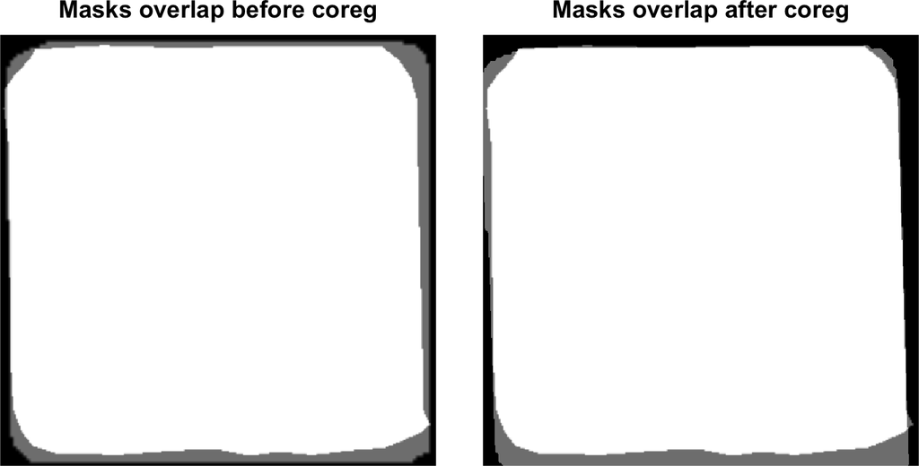

```r
ol3 <- t(opt_roi_ss * 0.5 + mse_roi_ss * 0.5)
ol4 <- t(opt_roi_ss * 0.5 + mse_roi_ss_x * 0.5)

height <- 7
width <- (height * 2) * (dim(ol3)[2] / dim(ol3)[1])

pl <- layout(mat=matrix(c(1:2), ncol=2, byrow=TRUE),
             heights=height, widths=rep(width/2, 2),
             respect=TRUE)
titles <- c("Masks overlap before coreg", "Masks overlap after coreg")
par(mar=c(0.25, 0.25, 0.75, 0.25))
. <- sapply(c(1:2), function(x) {
    plot.new()
    rasterImage(list(ol3, ol4)[[x]],
                xleft=0, xright=1, ytop=0, ybottom=1,
                interpolate=FALSE)
    title(titles[x])
})
par(def.par)
```

The left plot shows the overlay of optical and MS image tissue outlines prior to and post coregistration. The color white and black means that the tissue outline areas are aligned and the color gray implies the areas are not aligned. It is clear that the right plot has more alignment (less gray area) than the left plot. From this plot, we check that the overall gray area is reduced (or ideall zero).

## 8.2 Normalized cross correlation

$$NCC = \frac{\sum_{i=1}^{M}\sum_{j=1}^{N} (A(i,j) - \bar{A})(B(i,j) - \bar{B})}{\sqrt{\sum_{i=1}^{M}\sum_{j=1}^{N}(A(i,j) - \bar{A})^2 \sum_{i=1}^{M}\sum_{j=1}^{N}(B(i,j) - \bar{B})^2}}$$

```r
ncc_prereg <- normalizedCrossCorr(.fixed, .moving)
ncc_postreg <- normalizedCrossCorr(.fixed, .movingx)
```

The `ncc` values before and after coregistration are -0.117 and 0 respectively.

## 8.3 Mutual information

While mutual information (MI) is a very effective at evaluting the similarity between two images that have different intensity ranges and scales, we are using it for optimizing the coregistration routine. So, evaluating the coregistration performance on this metric is not recommended. MI is also a global metric.

However, here is a way to evaluate MI on the images before and after registration.

```r
# Metric before coregistration
mi_before <- out$reg$reg$MetricEvaluate(out$fixed, out$moving)

mi_after <- out$reg$reg$MetricEvaluate(out$fixed, out$movingx)

print(paste0("MI metric before registration: ", round(mi_before, 4)))
print(paste0("MI metric after registration: ", round(mi_after, 4)))
```

[output not shown]

## 8.4 Dense vector field jacobian determinant

This metric evaluates the local coregistration quality by applying a jacobian determinant on the dense vector field transformation. Dense vector field is the evaluation of every pixel location’s `x` and `y` displacements. Specifically, we want to look at the pixel folding which corresponds to negative jacobian determinant values. Folding occurs when neighboring pixels switch positions after transformation. So, when a pixel that is to be left of a neighboring pixel has shifted to the right of that neighboring pixel after transformation.

Imagine a canvas where you want get the right edge of the canvas to the left side of the left edge. The only way to do this is to fold the right edge over the left edge. This is why we check the jacobian determinant for “folding” in the transformed image.

Values

- = 1 imply no area (or volume) change
- (> 1) imply increased area or expansion
- (1, 0) imply reduced area or shrinkage
- < 0 imply folding <- this is bad

First, we plot a histogram of the jacobian determinant to visualize the distribution of the values. We can see, almost all values are centered around 1, which means the transformations are elastic and very superficial. The red and blue dotted lines show transformations where area has shrunk or expanded by 2 times respectively.

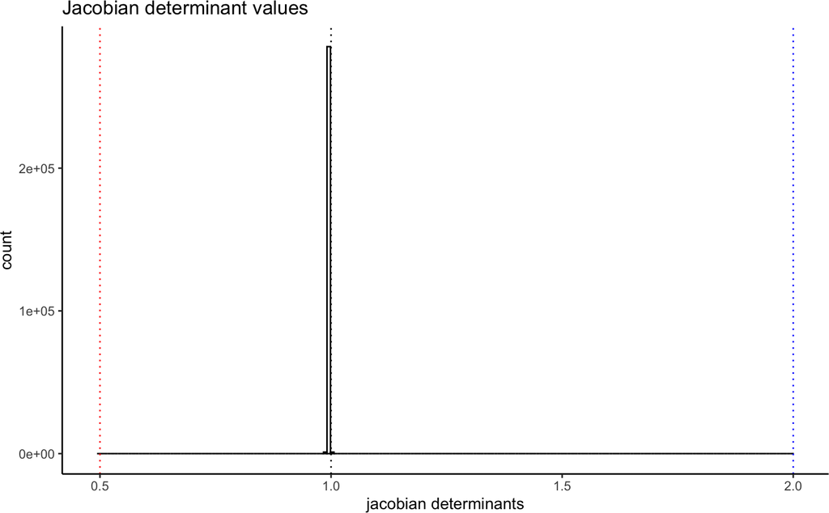

```r
jac <- jacobianDeterminantFromTransform(out$reg$TF, ref_img=out$moving)
jac_hist <- data.frame(jac_hist=as.vector(jac$jacobian_det))
jac_hist$ind <- 1:nrow(jac_hist)

jac_hist |>
    ggplot(mapping=aes(x=jac_hist)) +
    geom_histogram(bins=200, color="black", fill="white") +
    geom_vline(xintercept=1, color="black", linetype="dotted") +
    geom_vline(xintercept=0.5, color="red", linetype="dotted") +
    geom_vline(xintercept=2, color="blue", linetype="dotted") +
    labs(x="jacobian determinants", y="count",
         title="Jacobian determinant values") +
    theme_classic()
```

The range of the determinant of the Jacobian is 0.9854637, 1.0035919. The number of pixel locations where folding has occurred is 0.

Next, we plot the jacobian determinants as an image. This will provide us with the spatial distribution of transformations similar to that of the transformed grid earlier. In this plot, we also see the strength of the transformation. The darker (more intensity) the region is, the more warped it is.

[figure not shown]

```r
.jacdet <- jac$jacobian_det
.jacdet[.jacdet < 0] <- 0
.jacdet[.jacdet > 1] <- 1

def.par <- par(no.readonly=TRUE)
height <- 7
width <- height * (dim(.jacdet)[1] / dim(.jacdet)[2])

titles <- c("Jacobian determinants")

par(mar=c(0.25, 0.25, 0.75, 0.25))
pl <- layout(mat=matrix(c(1:1), ncol=1, byrow=TRUE),
             heights=height, widths=width,
             respect=TRUE)

plot.new()
rasterImage(t(.jacdet),
            xleft=0, xright=1, ytop=0, ybottom=1,
            interpolate=FALSE)
title(titles[1])
par(def.par)
```

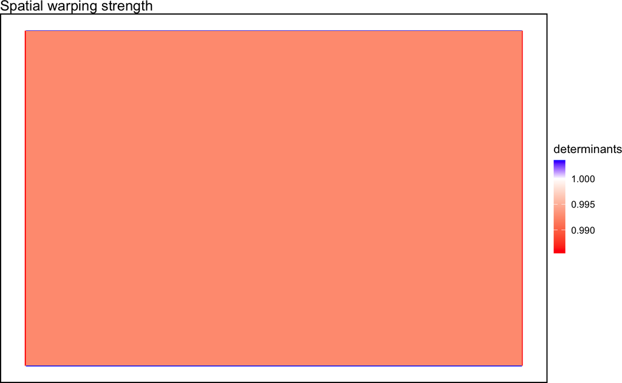

```r
jacdet <- jac$jacobian_det
jacdet[jacdet <= 0] <- 0
d <- dim(jacdet)

# Create a mesh with x and y as coordinates of the plot
# and z as the jacdet intensity
jacdet_mesh <- expand.grid(x=c(1:d[1]), y=c(1:d[2]))
jacdet_mesh$ints <- c(flip(jacdet))

jacdet_mesh |>
    ggplot(mapping=aes(x=x, y=y)) +
    geom_tile(aes(fill=ints)) +
    scale_fill_gradientn("determinants", colors=c("red", "white", "blue"),
                         values=scales::rescale(c(min(jacdet), 1, max(jacdet)))) +
    labs(title="Spatial warping strength") +
    theme_void() +
    theme(panel.border=element_rect(color="black", fill=NA, linewidth=1),
          legend.key.width=unit(0.75, "lines"))
```

## 8.5 Gradient field cosine distance

The final performance metric is the gradient field cosine distance visualized spatially. Put simply, the images are a measure of cosine distance between the following image gradient pairs.

- fixed and moving image pair
- fixed and transformed moving image pair

```r
img1 <- .fixed
img2 <- .moving
img2x <- .movingx

grads1 <- matrixGradients(imageData(img1))
grads2 <- matrixGradients(imageData(img2))
grads2x <- matrixGradients(imageData(img2x))

.grads1 <- normalizeGradients(grads1)
.grads2 <- normalizeGradients(grads2)
.grads2x <- normalizeGradients(grads2x)

D <- dim(img1)

.grads <- array(c(.grads1, .grads2), dim=c(D, 4))
cos_dist <- apply(.grads, c(1,2), function(x) {
    if (identical(x[c(1:2)], x[c(3:4)])) return(1)

    (sum( x[c(1:2)] * x[c(3:4)] ))
}) |>
    array(dim=dim(img1))


.gradsx <- array(c(.grads1, .grads2x), dim=c(D, 4))
cos_distx <- apply(.gradsx, c(1,2), function(x) {
    if (identical(x[c(1:2)], x[c(3:4)])) return(1)

    (sum( x[c(1:2)] * x[c(3:4)] ))
}) |>
    array(dim=dim(img1))
```

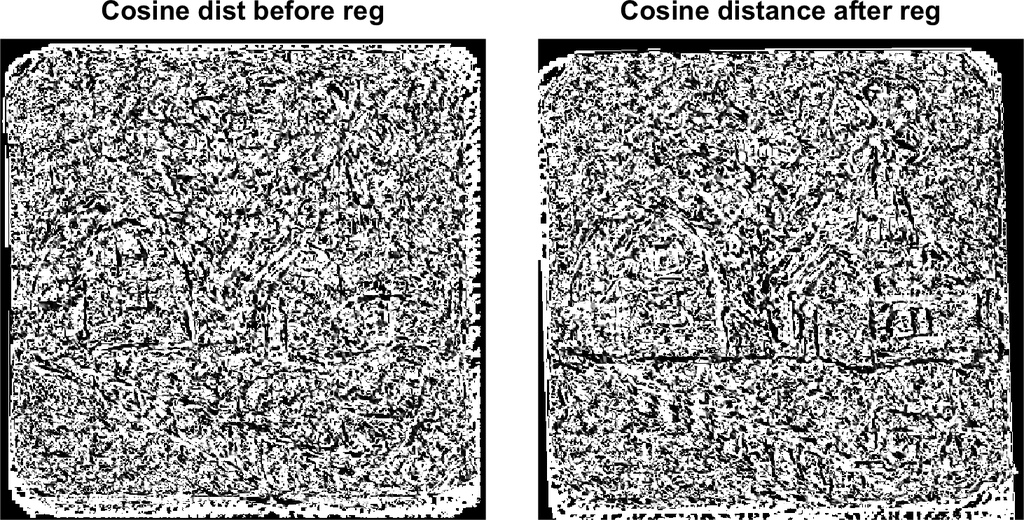

```r
height <- 3.5
width <- 7 * (dim(.fixed)[1] / dim(.fixed)[2])

pl <- layout(mat=matrix(c(1:2), ncol=2, byrow=TRUE),
             heights=height, widths=rep(width/2, 2),
             respect=TRUE)
titles <- c("Cosine dist before reg", "Cosine distance after reg")
par(mar=c(0.25, 0.25, 0.75, 0.25))
. <- sapply(c(1:2), function(x) {
    plot.new()
    rasterImage(list(t(1-cos_dist), t(1-cos_distx))[[x]],
                xleft=0, xright=1, ytop=0, ybottom=1,
                interpolate=FALSE)
    title(titles[x])
})
par(def.par)
```

Any systemic differences between these image pairs are picked up on by the metric. Informally, we look for any discernable morphology (like edges of heterogenous tissue regions). within both plots. Ideally, the plot on the right should not show any structures. However, if the right plot shows more structures in the right plot, it implies a bad coregistration.

# 9 Computational details